# Assignment4Q1

## 2c. Make a barplot of major_count

```
library("plyr")
MajorCountBarPlot <- count(major_count)
count(major_count)
barplot(MajorCountBarPlot$freq, horiz = TRUE, col = 'green', names= MajorCountBarPlot$x, xlim=c(0,30), xlab =     "Major Category", main = 'Majors by Major Category')
```

### Output for 2c.

```r
library("plyr")
MajorCountBarPlot <- count(major_count)
count(major_count)
```

```
##                                      x freq
## 1      Agriculture & Natural Resources   10
## 2                                 Arts    8
## 3               Biology & Life Science   14
## 4                             Business   13
## 5          Communications & Journalism    4
## 6              Computers & Mathematics   11
## 7                            Education   16
## 8                          Engineering   29
## 9                               Health   12
## 10           Humanities & Liberal Arts   15
## 11 Industrial Arts & Consumer Services    7
## 12                   Interdisciplinary    1
## 13                 Law & Public Policy    5
## 14                   Physical Sciences   10
## 15            Psychology & Social Work    9
## 16                      Social Science    9
```

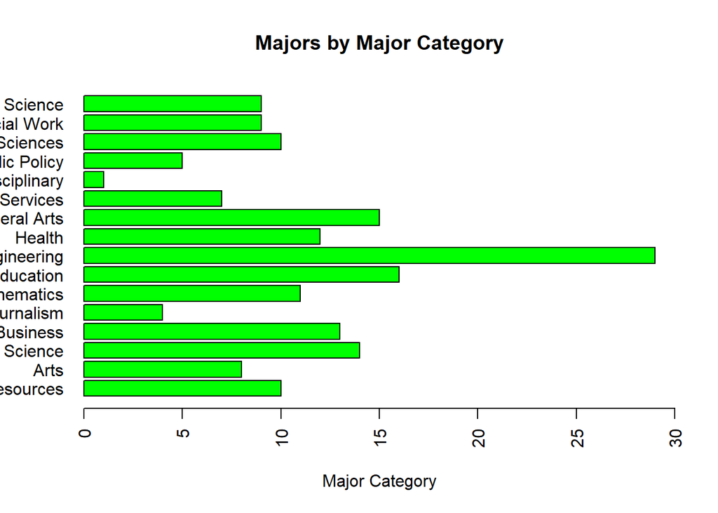

```r
par(las=2)
barplot(MajorCountBarPlot$freq, horiz = TRUE, col = 'green', names= MajorCountBarPlot$x, xlim=c(0,30), xlab =     "Major Category", main = 'Majors by Major Category')
```

## 2d. Write the fivethirtyeight data to a csv file.

```r
write.csv(df, file = "fivethirtyeight.csv",row.names=FALSE)
```

## 3a. Start a new repository on GitHub for your SMU MSDS homework.Add whatever you would like to this repo.

```
https://github.com/ashasaxena/SMU
```

## 3b. Create a README.md file which explains the purpose of the repository

```
https://github.com/ashasaxena/SMU/blob/master/Assignment04/README.md
```

## 3c. In one (or more) of the nested directories, post your RMarkdown script, HTML file,and data from ‘fivethirtyeight.’

```
https://github.com/ashasaxena/SMU/tree/master/Assignment04
```

### Make sure that in your README or elsewhere that you credit fivethirtyeight in some way.

```
https://github.com/ashasaxena/SMU/blob/master/Assignment04/README.md
```

## 3d. In your RMarkdown script, please provide the link to this GitHub so the grader can see it.

```
See above.
```